# Part I - Ford GoBike Data Exploration 2019

## Introduction

> This data set includes individual rides made in a bike-sharing system covering the greater San Francisco Bay area for one month, February 2019.

## Preliminary Wrangling

```python
# import all packages and set plots to be embedded inline
import numpy as np
import pandas as pd
import matplotlib.pyplot as plt
import seaborn as sb
import matplotlib.ticker
import matplotlib.dates as mdates

from matplotlib.dates import AutoDateLocator, AutoDateFormatter, date2num
from matplotlib.dates import DayLocator, HourLocator

%matplotlib inline
```

```python
# Setting the size of all plots
plt.rcParams['figure.figsize'] = 12, 5

# and setting the colors
color = ["#1A374D","#4b85a8", "#406882","#7C99AC","#d98100"]

sb.set()
sb.set_style("whitegrid", {"grid.color": ".1", "grid.linestyle": ""})
sb.despine();
```

#### Functions for visualization plots.

```python
def title_labels(title,xlabel,ylabel):
    """Get the data and add labels and title to the plot.

    Args:
      labels (str): A sequence of strings providing the labels for each wedge
      title(str): The title for the plot. """

    # Set axis labels
    ax.set_xlabel(xlabel, fontsize=13)
    ax.set_ylabel(ylabel, fontsize=13)
    ax.set_title(title, fontsize=15);
```

```python
def hist_scale(data,xlabel, ylabel, title):
    """Get the data and plot a scaled histogram with labels.

    Args:
      data (pandas DataFrame): The DataFrame with a specific column to plot.
      labels (str): A sequence of strings providing the labels for each wedge
      title(str): The title for the plot.


    Returns:
      histogram
    """
    data = df['duration_sec']
    plt.figure(figsize=[12, 5])
    ax = sb.histplot(data, log_scale=True)
    ax.xaxis.set_major_formatter(matplotlib.ticker.ScalarFormatter())
    ax.set_xticks( np.geomspace(min(data), max(data),15).round());

    plt.title(title)
    plt.xlabel(xlabel)
    plt.ylabel(ylabel)

    ax.axvline(
              x=data.median(),
              color="#d98100",
              label="Median: " + str(int(data.median())),
              linestyle='--', linewidth=2
              )

    ax.axvline(
              x=data.mean(), color="#d98100",
              label="Mean: " + str(int(data.mean())),
              linestyle='-',
              linewidth=2
              )



    ax.legend()

    plt.show()
```

```python
def plotting_histplot(data, title):
    """Get the data and plot histplot with median and mean

    Args:
      data (pandas DataFrame): The DataFrame with specific columns to plot.


    Returns:
      histplot
    """
    # Initalize a figure and axes
    fig, axes = plt.subplots(ncols=1, nrows=1)

    # Plot the data
    sb.histplot(data)

    axes.axvline(
              x=data.median(),
              color="#d98100",
              label="Median: " + str(int(data.median())),
              linestyle='--', linewidth=2
              )

    axes.axvline(
              x=data.mean(), color="#d98100",
              label="Mean: " + str(int(data.mean())),
              linestyle='-',
              linewidth=2
              )

    axes.set_title(title, size = 14)

    axes.legend()

    plt.show()
```

```python
# Function for pie plot
def plot_pie(data,labels, title):
    """Get the data and pie plot with labels

    Args:
      data (pandas DataFrame): The DataFrame with a specific numeric column to plot.
      labels (list): A sequence of strings providing the labels for each wedge
      title(str): The title for the plot.


    Returns:
      pie plot
    """
    ax = plt.figure(figsize = (4.5,4.5))

    ax = plt.pie(data, labels = labels,
                 autopct='%1.0f%%',startangle = 90,
                 textprops={'fontsize': 13}  )

    plt.title(title, fontsize=15)
```

```python
def countplot_h(data, title):
    """Get dataframe specific column and count the amount of each type,
       and plot horizontal bars with labels.

    Args:
      data (pandas DataFrame): The DataFrame with specific columns to plot.
      title (str): The title for the plot.


    Returns:
      plot horizontal bars
    """

     # Plotting data
    ax = sb.countplot(y = data, order = data.value_counts().index,palette = "PuBuGn_d");

    # Set labels and legend
    ax.set_title(title, fontsize=18)
    plt.rc('legend', fontsize=13)

    # Patches is everything inside of the chart
    for rect in ax.patches:
        # Find where everything is located
        height = rect.get_height()
        width = rect.get_width()
        x = rect.get_x()
        y = rect.get_y()

        # The height of the bar is the data value and can be used as the label
        label_text = f'{width:.0f}'

        # ax.text(x, y, text)
        label_x = x + width/2
        label_y = y + height/2

        # plot only when height is greater than specified value
        if height > 0:
            ax.text(
                label_x,
                label_y,
                label_text,
                ha='center',
                va='center',
                fontsize=14
                )

    ax.set_title(title, size = 14)
    plt.show()
```

```python
def plot_bar_h(data, xlabel, ylabel, title):
    """Get the data and plot vertical bars

    Args:
      data (pandas DataFrame): The DataFrame with specific columns to plot.
      xlabel (str): The label for x axis.
      ylabel (str): The label for y axis.
      title (str): The title for the plot.


    Returns:
      plot bars
    """
    # Plotting data
    ax = data.plot.barh(figsize=(9,4))

    # Set labels and legend
    ax.set_xlabel(xlabel, fontsize=12)
    ax.set_ylabel(ylabel, fontsize=12)
    ax.set_title(title, fontsize=15)

    #plt.xticks(rotation=45)

    ax.legend(loc='best')
    plt.rc('legend', fontsize=12)

    # Patches is everything inside of the chart
    for rect in ax.patches:
        # Find where everything is located
        height = rect.get_height()
        width = rect.get_width()
        x = rect.get_x()
        y = rect.get_y()

        # The height of the bar is the data value and can be used as the label
        label_text = f'{width:.0f}'

        # ax.text(x, y, text)
        label_x = x + width/2
        label_y = y + height/2

        # plot only when height is greater than specified value
        if height > 0:
            ax.text(
                label_x,
                label_y,
                label_text,
                ha='center',
                va='center',
                fontsize=13
                )
```

```python
def stacked_bars_h (data, title, xlabel, ylabel):
    """Get the data and plot horizontal stacked bars with title and labels

    Args:
      data (pandas DataFrame): The DataFrame with specific columns to plot.
      xlabel (str): The label for x axis.
      ylabel (str): The label for y axis.
      title (str): The title for the plot.

    Returns:
      plot horizontal stacked bars
    """
    ax = data.plot.barh(stacked=True, color=color[1:3])


    # Set labels and legend
    ax.set_xlabel(xlabel, fontsize=13)
    ax.set_ylabel(ylabel, fontsize=13)
    ax.set_title(title, fontsize=15)

    ax.legend(loc='lower right')
    plt.rc('legend', fontsize=13)

    # Patches is everything inside of the chart
    for rect in ax.patches:
    # Find where everything is located
        height = rect.get_height()
        width = rect.get_width()
        x = rect.get_x()
        y = rect.get_y()

    # The height of the bar is the data value and can be used as the label
        label_text = f'{width:.0f}'

    # ax.text(x, y, text)
        label_x = x + width / 2
        label_y = y + height / 2

    # plot only when height is greater than specified value
        if height > 0:
            ax.text(label_x, label_y,
            label_text, ha='center',
            va='center', fontsize=13)
```

### The structure of the dataset.

Data has 183412 rows and 16 columns. Data includes information about users, bike stations, duration of the rides. Information about users contains: user type( customer or subscriber), birth year, and gender.

### The main features of interest in the dataset.

In this project, I will focus on user-related features: `user_type`, `member_birth_year`, and `member_gender`.

Features `duration_sec`, `star - end time` will help investigate users' behavior.

### Data Gathering

Directly download the "201902-fordgobike-tripdata.csv" data file with pd.read_csv() function.

```python
# Read in the csv file
df_bike = pd.read_csv("201902-fordgobike-tripdata.csv")
```

```python
df_bike.sample(3)
```

|  | duration_sec | start_time | end_time | start_station_id | start_station_name | start_station_latitude | start_station_longitude | end_station_id | end_station_name | end_station_latitude | end_station_longitude | bike_id | user_type | member_birth_year | member_gender | bike_share_for_all_trip |
| --- | --- | --- | --- | --- | --- | --- | --- | --- | --- | --- | --- | --- | --- | --- | --- | --- |
| 46730 | 844 | 2/22/19 9:18:33 | 2/22/19 9:32:37 | 16.0 | Steuart St at Market St | 37.794130 | -122.394430 | 126.0 | Esprit Park | 37.761634 | -122.390648 | 6234 | Subscriber | 1971.0 | Male | No |
| 70540 | 928 | 2/19/19 18:04:49 | 2/19/19 18:20:18 | 156.0 | Stanford Ave at Hollis St | 37.838443 | -122.288665 | 160.0 | West Oakland BART Station | 37.805318 | -122.294837 | 5514 | Subscriber | 1963.0 | Female | No |
| 8063 | 323 | 2/28/19 8:40:29 | 2/28/19 8:45:52 | 93.0 | 4th St at Mission Bay Blvd S | 37.770407 | -122.391198 | 126.0 | Esprit Park | 37.761634 | -122.390648 | 5878 | Subscriber | 1989.0 | Male | No |

### Assessing Data

Assess data divided into two types: **quality and tidiness.** Quality issues are issues with the content. Tidiness issues are issues with a structure.

```python
# Inspect data
df_bike.head(2)
```

|  | duration_sec | start_time | end_time | start_station_id | start_station_name | start_station_latitude | start_station_longitude | end_station_id | end_station_name | end_station_latitude | end_station_longitude | bike_id | user_type | member_birth_year | member_gender | bike_share_for_all_trip |
| --- | --- | --- | --- | --- | --- | --- | --- | --- | --- | --- | --- | --- | --- | --- | --- | --- |
| 0 | 52185 | 2/28/19 17:32:10 | 3/1/19 8:01:56 | 21.0 | Montgomery St BART Station (Market St at 2nd St) | 37.789625 | -122.400811 | 13.0 | Commercial St at Montgomery St | 37.794231 | -122.402923 | 4902 | Customer | 1984.0 | Male | No |
| 1 | 42521 | 2/28/19 18:53:22 | 3/1/19 6:42:03 | 23.0 | The Embarcadero at Steuart St | 37.791464 | -122.391034 | 81.0 | Berry St at 4th St | 37.775880 | -122.393170 | 2535 | Customer | NaN | NaN | No |

```python
# Print data information
df_bike.info()
```

```
<class 'pandas.core.frame.DataFrame'>
RangeIndex: 183412 entries, 0 to 183411
Data columns (total 16 columns):
 #   Column                   Non-Null Count   Dtype
---  ------                   --------------   -----
 0   duration_sec             183412 non-null  int64
 1   start_time               183412 non-null  object
 2   end_time                 183412 non-null  object
 3   start_station_id         183215 non-null  float64
 4   start_station_name       183215 non-null  object
 5   start_station_latitude   183412 non-null  float64
 6   start_station_longitude  183412 non-null  float64
 7   end_station_id           183215 non-null  float64
 8   end_station_name         183215 non-null  object
 9   end_station_latitude     183412 non-null  float64
 10  end_station_longitude    183412 non-null  float64
 11  bike_id                  183412 non-null  int64
 12  user_type                183412 non-null  object
 13  member_birth_year        175147 non-null  float64
 14  member_gender            175147 non-null  object
 15  bike_share_for_all_trip  183412 non-null  object
dtypes: float64(7), int64(2), object(7)
memory usage: 22.4+ MB
```

```python
df_bike.describe()
```

|  | duration_sec | start_station_id | start_station_latitude | start_station_longitude | end_station_id | end_station_latitude | end_station_longitude | bike_id | member_birth_year |
| --- | --- | --- | --- | --- | --- | --- | --- | --- | --- |
| count | 183412.000000 | 183215.000000 | 183412.000000 | 183412.000000 | 183215.000000 | 183412.000000 | 183412.000000 | 183412.000000 | 175147.000000 |
| mean | 726.078435 | 138.590427 | 37.771223 | -122.352664 | 136.249123 | 37.771427 | -122.352250 | 4472.906375 | 1984.806437 |
| std | 1794.389780 | 111.778864 | 0.099581 | 0.117097 | 111.515131 | 0.099490 | 0.116673 | 1664.383394 | 10.116689 |
| min | 61.000000 | 3.000000 | 37.317298 | -122.453705 | 3.000000 | 37.317298 | -122.453705 | 11.000000 | 1878.000000 |
| 25% | 325.000000 | 47.000000 | 37.770083 | -122.412408 | 44.000000 | 37.770407 | -122.411726 | 3777.000000 | 1980.000000 |
| 50% | 514.000000 | 104.000000 | 37.780760 | -122.398285 | 100.000000 | 37.781010 | -122.398279 | 4958.000000 | 1987.000000 |
| 75% | 796.000000 | 239.000000 | 37.797280 | -122.286533 | 235.000000 | 37.797320 | -122.288045 | 5502.000000 | 1992.000000 |
| max | 85444.000000 | 398.000000 | 37.880222 | -121.874119 | 398.000000 | 37.880222 | -121.874119 | 6645.000000 | 2001.000000 |

```python
df_bike.shape
```

```
(183412, 16)
```

```python
df_bike.duplicated().sum()
```

```
0
```

```python
df_bike.isnull().sum()
```

```
duration_sec                  0
start_time                    0
end_time                      0
start_station_id            197
start_station_name          197
start_station_latitude        0
start_station_longitude       0
end_station_id              197
end_station_name            197
end_station_latitude          0
end_station_longitude         0
bike_id                       0
user_type                     0
member_birth_year          8265
member_gender              8265
bike_share_for_all_trip       0
dtype: int64
```

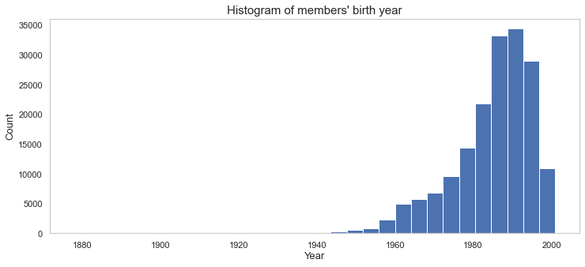

```python
ax = df_bike["member_birth_year"].hist(bins = 30)

# Set axis labels
title_labels("Histogram of members' birth year","Year","Count");
```

### Quality issues

1. The columns `start_time` and `end_time` have an object data type.
2. The data contain unrealistic customers' birth years, such as 1878.
3. Columns with null values
4. The Data has redundant columns with latitude and longitude information.

### Tidiness issues

1. `start_time` and `end_time` columns contain date and time on one column
2. Absent weekday column.
3. Absent the customers' age column.

### Cleaning Data

Cleaning all documented issues from the assessment section.

```python
# Make copies of original pieces of data
df = df_bike.copy()
```

#### Issue #1: The columns `start_time` and `end_time` have an object data type.

Define: Date and time data have to be in DateTime format.

```python
# Convert "start_time" and "end_time" to a date-time
df["start_time"] = pd.to_datetime(df["start_time"])
df["end_time"] = pd.to_datetime(df["end_time"])
```

#### Issue #2: The data contain unrealistic customers' birth years, such as 1878.

Define: To avoid redundancy and outliers, we will use `member_birth_year` no less than the 1945 year.

```python
# Use query() function to select data
df = df.query("member_birth_year > 1945.0")
```

#### Issue #3: Columns with null values.

Define: The columns contain null values. We will drop all null rows.

```python
# Drop missing values
df = df.dropna()
```

#### Issue #4: The Data has redundant columns with latitude and longitude information.

Define:In this case, latitude and longitude information is useless; we will drop those columns.

```python
# Drop unnecessary columns
col = ["start_station_latitude", "start_station_longitude",
       "end_station_latitude", "end_station_longitude",
        "start_station_id", "end_station_id", "bike_id",
       "bike_share_for_all_trip"]

df = df.drop(col, axis = 1)
```

#### Issue #5: `start_time` and `end_time` columns contain date and time on one column.

Define: Extract the time information from `start_time` and `end_time` columns

```python
# Extract the hours of the datetime
df['start_hour'] = df['start_time'].dt.hour
df['end_hour'] = df['end_time'].dt.hour
```

#### Issue #6: Absent weekday column.

Define: Initiate weekday column.

```python
# Extract the weekdays
df['start_weekday'] = df['start_time'].dt.day_name()
```

#### Issue #7: Absent the customers' age column.

Define: Data has a customers' birth years column; therefore, we will calculate customers' age and initiate a new column.

```python
# Initiate "member_age" column
df["member_age"] = (2019 - df["member_birth_year"]).astype(int)
```

```python
df.head(1)
```

|  | duration_sec | start_time | end_time | start_station_name | end_station_name | user_type | member_birth_year | member_gender | start_hour | end_hour | start_weekday | member_age |
| --- | --- | --- | --- | --- | --- | --- | --- | --- | --- | --- | --- | --- |
| 0 | 52185 | 2019-02-28 17:32:10 | 2019-03-01 08:01:56 | Montgomery St BART Station (Market St at 2nd St) | Commercial St at Montgomery St | Customer | 1984.0 | Male | 17 | 8 | Thursday | 35 |

```python
df.shape
```

```
(174582, 12)
```

## Section 1: Univariate Exploration

> In this section we will investigate distributions of individual variables. I will use the *"Question-Visualization-Observations"* framework throughout the exploration. This framework involves **asking a question from the data, creating a visualization to find answers, and then recording observations after each visualisation.**

### Who are Ford GoBike users?

- What is the ratio of the users' type? What is the primary group "Customer" or "Subscriber"?
- What is the primary users' gender?
- How the distribution of users' age looks?

We will use the following features to answer those questions: `user_type`, `member_gender`, `member_age`.

#### What is the ratio of the users' type? What is the primary group "Customer" or "Subscriber"?

We will use a pie plot to determine which type of users is more significant.

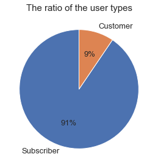

```python
# Use the plot_pie function to plot the ratio of the user types
plot_pie(df.user_type.value_counts(),df.user_type.value_counts().index, "The ratio of the user types")
```

The pie plot shows that 91% of users are subscribers, and only 9% describe customers.

#### What is the primary users' gender?

To count every type of gender in the dataset, we will use a horizontal bar plot.

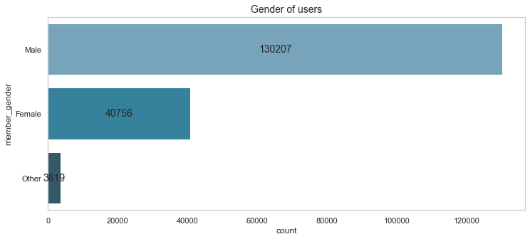

```python
# Use the countplot_h function to discover gender proportion
countplot_h(df.member_gender, "Gender of users")
```

The count plot shows that most users are **males**, which is 130207 users or **75%**. **Females** have **23%** or 40756 users, and **others** make up **2%**.

#### How the distribution of users' age looks?

A histogram is the best way to show distribution. Also, I added average and median values to the plot.

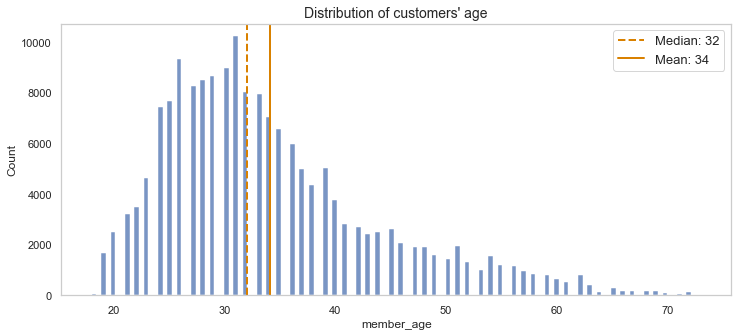

```python
# Use plotting_histplot() function to plot age distribution
plotting_histplot(df['member_age'], "Distribution of customers' age")
```

The histogram plot shows that most users' ages are between 25 and 35 years old. Meanwhile, the **average** age is **34 years old**, and the **median is 32 years old**.

### How do users use Ford GoBike service?

- How long are trips duration?
- What day of week and time of day do users prefer mostly?
- What are the users' favorite stations?

#### How long are rides duration?

The data has a column of duration, which is measured in seconds. To see the duration of all rides, we will also use a histogram, but we have to use scaling for better visualization.

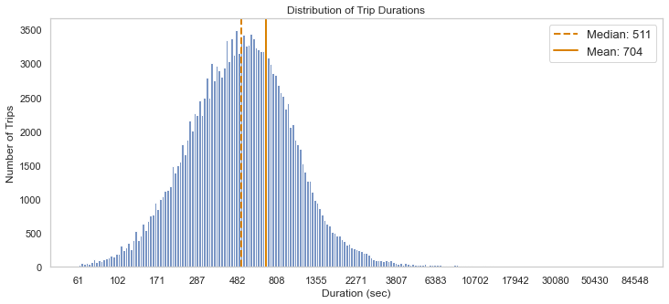

```python
# Use hist_scale function to build duration distribution
hist_scale(df['duration_sec'],
           xlabel = 'Duration (sec)',
           ylabel = 'Number of Trips',
           title ='Distribution of Trip Durations')
```

The distribution shows that the **average** trip duration is 704 sec or **11.7 min**, and the **median** is 511 or **8.5 min**. Durations of rides take on a vast range of values, from 61 seconds at the lowest to 84548 seconds at the highest.

#### What day of week and time of day do users prefer mostly?

In the cleaning section, we added a new column with a day of weeks. And now we will count what day is more popular.

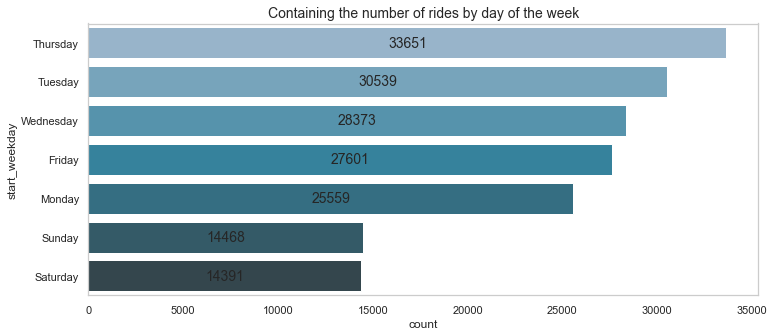

```python
# Use countplot_h function
countplot_h(df.start_weekday, "Containing the number of rides by day of the week")
```

The most popular day is Thursday. Less popular are Sunday and Saturday.

#### What time do users usually start and end rides?

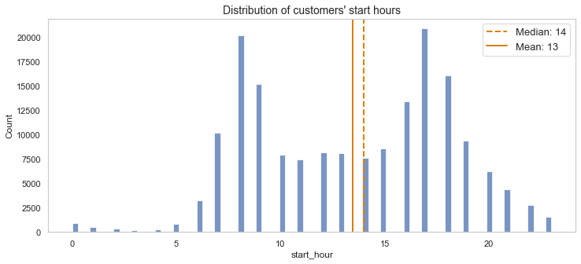

```python
# Use plotting_histplot() function to plot start time distribution
plotting_histplot(df['start_hour'], "Distribution of customers' start hours")
```

The start time of rides histogram shows two spikes around 8-9 am and 5-6 pm

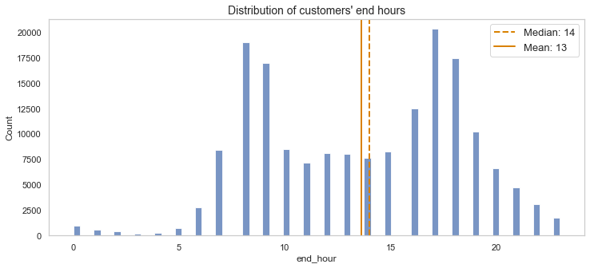

```python
# Use plotting_histplot() function to plot end time distribution
plotting_histplot(df['end_hour'], "Distribution of customers' end hours")
```

#### What is the preferred station?

`'start_station_name'` and `'end_station_name'` contain **329 unique stations**. We will use plot_bar() function to count and plot 10 most popular station.

[figure not shown]

```python
# Use plot_bar() function to explore most popular station
plot_bar_h(df['start_station_name'].value_counts()[:10],
        "Count","","Bar plot of 10 most popular stations where START rides")
```

Bar plot shows that the most popular starting stations are: Market St at 10th St, San Francisco Caltrain Station 2 (Townsend St at 4th St), and Berry St at 4th St.

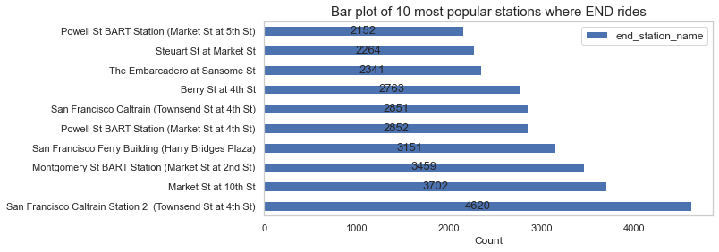

```python
# Use plot_bar() function to explore most popular station
plot_bar_h(df['end_station_name'].value_counts()[:10],
        "Count","","Bar plot of 10 most popular stations where END rides")
```

Bar plot shows that the most popular ending stations are: San Francisco Caltrain Station 2 (Townsend St at 4th St) ,Market St at 10th St , Montgomery St BART Station (Market St at 2nd St)

#### Conclusions

To investigate the questions about users and how they use the Ford GoBike service, we used several plots: **pie, count, bars, histogram, and scaled histogram.**

When I built a histogram for rides duration, I noticed that most rides lie under 1000 seconds, which causes the distribution to be skewed, with most of the distribution crowded into a small part of the graph. Hence, it's hard to tell where the median or mean should be on the histogram. I put the x-axis on a log scale to make the histogram more informative to solve this problem. As a result, we have a **median ride of 511 seconds and an average ride of 704 seconds.**

One of the things that surprised me is that **most rides occur on Thursday** and the less popular days are Saturday and Sunday.

## Section 2: Bivariate Exploration

> This section will investigate relationships between pairs of variables in data that we covered in the previous section (univariate exploration).
- What is the users' type ratio in each gender?
- What is the gender ratio by age? -What is the distribution of average duration rides by age?
- Who makes the longer average ride customer or subscribers?
- What days of the week are the most extended rides? -In what start time do users make the most duration?

#### What is the users' type ratio in each gender?

We need group member_gender by user type`groupby()`, count it, and plot with **stacked bars** to answer that question.

```python
# Use .groupby() and .value_counts() to create a  table
gender_usertype = df.groupby("member_gender")["user_type"].value_counts().unstack()
```

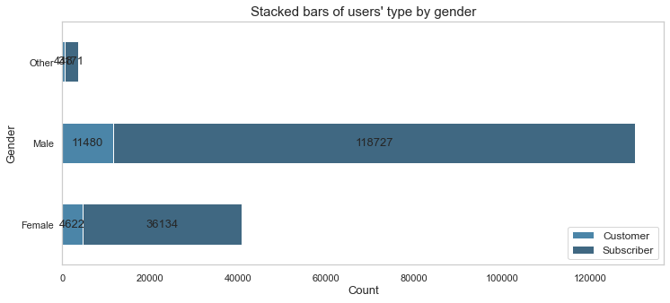

```python
# Create the stacked bar plot from the gender_usertype
stacked_bars_h (gender_usertype, "Stacked bars of users' type by gender", "Count", "Gender")
```

We can observe users' type by gender ratio on the stacked bars plot. The central part of each gender consists of the "Subscriber" user type. For **male `"Subscriber"` type equals 91%**, for females 89% and other 88%.

#### What is the gender ratio by age?

We know from the previous section that the average age is 34 years old, and the median age is 32 years old. Also, we know that 75% of all users are male, 23% are female, and 2% are others.

We will build violion plot(`sb.violinplot()`) to explore how users' age is distributed by gender.

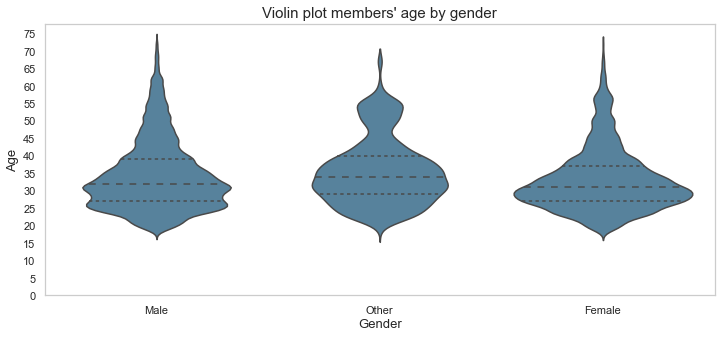

```python
# Make a violin plot
ax = sb.violinplot(data=df,y= "member_age", x='member_gender', inner = "quartile", color = color[1])

ax.set_yticks(np.arange(0, 75+1, 5))
title_labels("Violin plot members' age by gender","Gender","Age");
```

On the violin plot, we can observe that all gender have almost the same average age. The exact numbers are **34.33 y.o. for males, 33.15 for females, and 35.58 for others.** Also, we can see that the male and female groups have a nearly similar shape of figures.

#### What is the distribution of average duration rides by age?

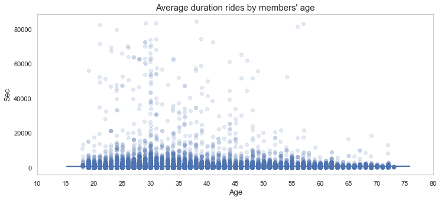

```python
# Group by the "member_age" and "duration_sec" and calculate the mean.
ave_dur_by_age = df.groupby("member_age")["duration_sec"].mean()

ax = sb.regplot(data = df, x = 'member_age',
                y = 'duration_sec',  ci=65,
                truncate=False,  x_jitter=.07,
                scatter_kws={'alpha':0.15})

# Set axis labels
title_labels("Average duration rides by members' age","Age","Sec")

ax.set_xticks(np.arange(10, 80+5, 5));
```

The graph shows more long average rides around 30 y.o.

#### Who makes the longer average ride customer or subscribers?

The average duration ride of the dataset is 704 seconds. Here we will explore how the duration of rides distributes by each user's type. We also will build a histogram and put the x-axis on a log scale.

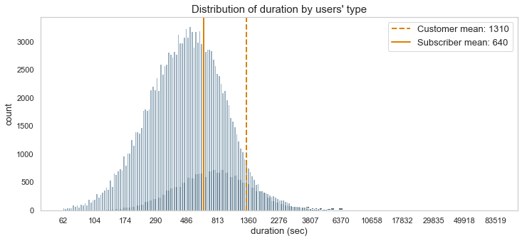

```python
# Select user_type equal to "Customer" and "Subscriber"
data = df.query('user_type == "Customer"').duration_sec
data1 = df.query('user_type == "Subscriber"').duration_sec

ax = sb.histplot(data, log_scale=True, color = color[0])
ax = sb.histplot(data1, log_scale=True, color = color[3])


ax.xaxis.set_major_formatter(matplotlib.ticker.ScalarFormatter())
ax.set_xticks(np.geomspace(min(data), max(data),15).round());

title_labels ("Distribution of duration by users' type", "duration (sec)", "count" )
ax.axvline(x=data.mean(),
           color="#d98100",
           label="Customer mean: " + str(int(data.mean())),
            linestyle='--', linewidth=2
              )

ax.axvline(x=data1.mean(), color="#d98100",
           label="Subscriber mean: " + str(int(data1.mean())),
            linestyle='-',
            linewidth=2
              )
ax.legend();
```

The histogram shows that the customers' mean 1310 seconds, and subscribers' mean is 640 seconds.

#### What days of the week are the most extended rides?

Weekdays have the most trips, and we will observe on which day users enjoy the longest ride.

```python
# Group days of the week by average ride duration with groupby() function
dur_days = df.groupby("start_weekday")["duration_sec"].mean()
```

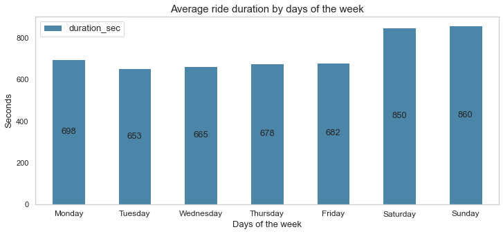

```python
# Plotting bar plot of average ride duration by days of the week
order = ['Monday', 'Tuesday', 'Wednesday','Thursday','Friday','Saturday','Sunday']
ax = dur_days.loc[order].plot(kind='bar', color = color[1])

# Set labels and legend
ax.set_xticklabels(dur_days.loc[order].index, rotation=0, fontsize=12)

title_labels("Average ride duration by days of the week","Days of the week","Seconds")

ax.legend(loc='best')
plt.rc('legend', fontsize=13)

# Patches is everything inside of the chart
for rect in ax.patches:
# Find where everything is located
    height = rect.get_height()
    width = rect.get_width()
    x = rect.get_x()
    y = rect.get_y()

    # The height of the bar is the data value and can be used as the label
    label_text = f'{height:.0f}'

    # ax.text(x, y, text)
    label_x = x + width/2
    label_y = y + height/2

    # plot only when height is greater than specified value
    if height > 0:ax.text(
                label_x,
                label_y,
                label_text,
                ha='center',
                va='center',
                fontsize=13)
```

According to the bar plot, **Saturday and Sunday** have the most extended rides on average.

#### In what start time do users make the most duration?

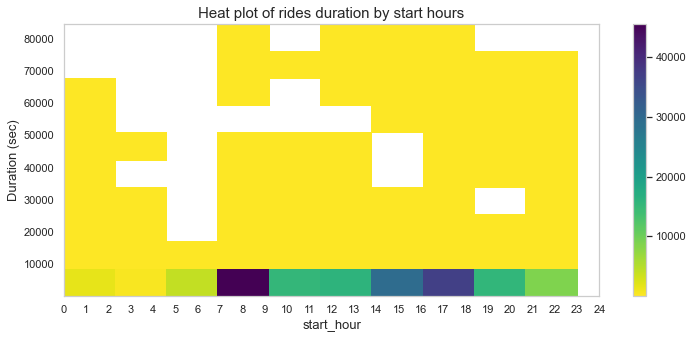

```python
# Generate a 2-D histogram
h2d = plt.hist2d(data = df, x ='start_hour', y = 'duration_sec', cmap = 'viridis_r', cmin = 0.5)
plt.colorbar()
plt.xlabel('start_hour', fontsize=13)
plt.ylabel('Duration (sec)', fontsize=13)
plt.title("Heat plot of rides duration by start hours", fontsize=15)
plt.xticks(np.arange(0, 24+1, 1));
```

Heat plot shows that most duration rides happen when users start at 7 - 9 am.

### Conclusion

Subscriber users' type is the dominant type in each gender. The average age of each gender is in the same age group: 30 - 35 y.o. Also, the same age group has the most longest rides on average.

An interesting finding is that even though subscribers make up 91% of all users, their average trip is 640 seconds, while the average ride duration for customers is 1310 seconds.

In section 1 we talk that Saturday and Sunday are less popular days according to the number of rides. Nonetheless, weekends days have the most longer duration rides on average than days of the week. On weekdays, the average duration is 677 seconds and for the weekend equals 855 seconds.

## Section 3: Multivariate Exploration

> In this section we will create plots of three or more variables to investigate data even further.

### What is the average ride duration for each day of week by users' type?

```python
# Group "start_weekday","user_type" by average "duration_sec"
aver_trip_weekdays_types = df.groupby(["start_weekday","user_type"])[["duration_sec"]].mean().reset_index()

aver_trip_weekdays_types = aver_trip_weekdays_types.pivot(index="start_weekday",
                                                          columns='user_type',
                                                          values='duration_sec')
```

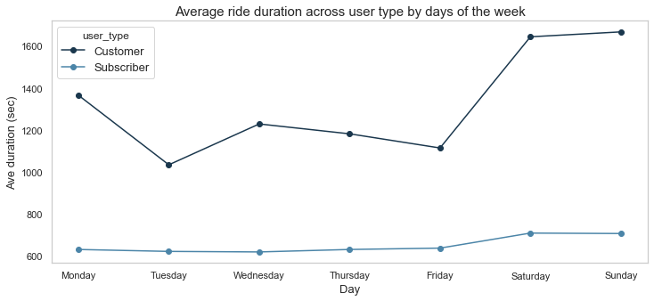

```python
# Plot the line graph
ax = aver_trip_weekdays_types.loc[order].plot.line(color=color,marker='o')

# Set axis labels and title
title_labels("Average ride duration across user type by days of the week",
             "Day","Ave duration (sec)")
```

On the line plot, we can see that on weekends average trip duration is much longer than on weekdays.

#### Conclusion

If we look at the line plot, we can see that the average ride duration among Subscribers does not change much depending on the days of the week. At the same time, the average ride duration among Customers rises sharply on weekends.

## Summary

Original data has 183412 rows and 16 columns. During assessment were detected four quality and three tidiness issues.

After fixing all issues shape of the data set contains 174582 rows and 12 columns. During the cleaning section, I dropped several columns such as station latitude longitude of start and end; stations id, because we have station names and it would be redundant keep all; etc.

In section 1 we investigated individual variables and found out that the **average user** of Ford GoBike is a male of 32-34 years old, a subscriber.

The less popular days of the week are Saturday and Sunday, but in section two, we discover that weekend has the most extended ride duration. That happens because the "Customer" users type uses the service mostly on weekends and have a long ride duration. While "Subscriber" takes the short ride on a working day and based on start time, I suggest it is a ride to work trip.

### Limitation

The main limitation of the data set is that it is only one month data. We can't make a conclusion by month and seasonality based on this data. Also, I would like to see more users' data; each user, each ride, cost of a ride. That data would be convenient for business decisions.